# LCA_analysis

Frederic Gnielka

2023-12-20

We begin by loading the required data set (“dataE_2112.sav”) into R. The selected variables are: gender, CASE, sexdrive2, CSBD, PPCS_6, meffort, socialanx, lon, mvalue, attr

The data set is split into one data frame for men and one for women, which are analysed separately, after the initial approach (i.e. investigating both genders at once with an LPA and OPTICS) did not result in an interpretable solution.

The performed analyses are exploratory.

The distributions of some of the variables are very skewed, and some categories are only inhabited by a few participants (see plots below).

Distributions male participants:

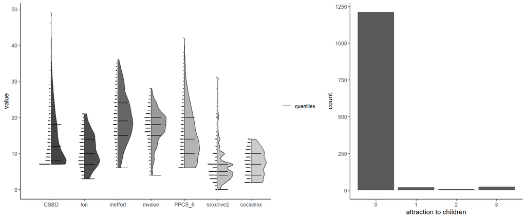

Distributions female participants:

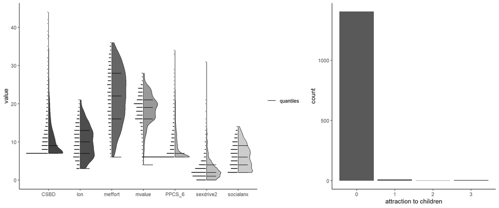

Therefore, we decided to split the scales into quantiles (see plots), and, when sufficient data to split the data into quantiles was not available, into dummy coded variables.

Let’s show some descriptives. Modus refers here to how many participants share this modal value. mode_value gives the actual modal value. v is a measure of variability for categorical variables and refers to the probability that two randomly drawn participants belong to different categories.

First we show males:

```
##        name            type    n missing unique mode    mode_value          v
## 1 sexdrive2 ordered, factor 1263       0      5  496         [0,4] 0.71727071
## 2      CSBD ordered, factor 1263       0      5  359         [7,8] 0.74828059
## 3    PPCS_6 ordered, factor 1263       0      5  368        [6,10] 0.74718603
## 4   meffort ordered, factor 1263       0      5  344        [6,15] 0.74901907
## 5 socialanx ordered, factor 1263       0      5  335        (7,10] 0.74924224
## 6       lon ordered, factor 1263       0      5  333         [3,7] 0.74970489
## 7    mvalue ordered, factor 1263       0      5  374        [4,15] 0.74353501
## 8      attr ordered, factor 1263       0      3 1211 no attraction 0.07895339
```

There are no missings, which is nice. With most variables we can observe that the quantile binning worked well (according to the v-values), except for the attraction to children variable. Even dichotomised too few few people report anything other than that they are completely unattracted to children.

Then females:

```
##        name            type    n missing unique mode    mode_value          v
## 1 sexdrive2 ordered, factor 1420       0      5  489         [0,1] 0.73406368
## 2   meffort ordered, factor 1420       0      5  396       (22,28] 0.74693216
## 3 socialanx ordered, factor 1420       0      5  511         [2,4] 0.72914699
## 4       lon ordered, factor 1420       0      5  445         [3,7] 0.74463995
## 5    mvalue ordered, factor 1420       0      5  386       (16,19] 0.74814124
## 6      attr ordered, factor 1420       0      3 1404 no attraction 0.02228129
## 7      CSBD ordered, factor 1420       0      3  717         [7,9] 0.49995140
## 8    PPCS_6 ordered, factor 1420       0      3  862         [6,7] 0.47708391
```

# Performing LCA

We begin with the data set comprised of males.

The steps include:  
1. Class enumeration  
2. Model evaluation  
3. Model interpretation

## Males

We look at the BIC criterion, which is presented as the most reliable measure for class enumeration in LCA according to simulation studies (Van Lissa, Garnier-Villarreal, and Anadria 2023; Masyn 2013).

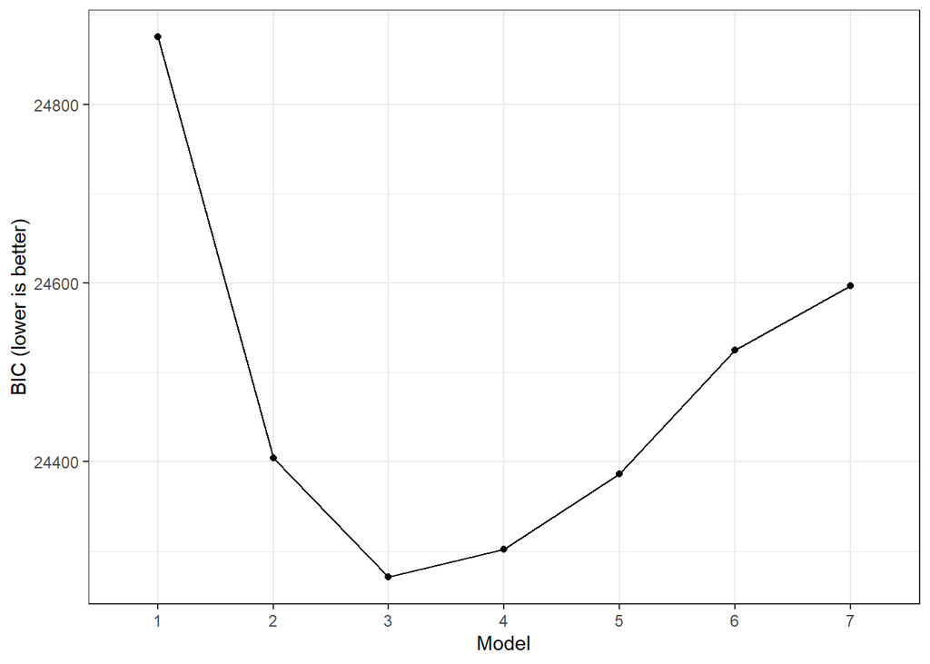

There appears to be a minimum being reached at three classes. The following table shows us how many participants are in which class

```
## $sum.posterior
##    class    count proportion
## 1 class1 381.4829  0.3020450
## 2 class2 313.6055  0.2483021
## 3 class3 567.9116  0.4496529
```

We did not calculate a likelihood ratio test (LRT), as Van Lissa, Garnier-Villarreal, and Anadria (2023) advise to be cautious using LRTs. This especially true in exploratory LCA because the conditions underlying the LRT are likely not met and the test results may be flawed or, as is the case with bootstrapped LRTs, they depend heavily on the model specifications and should better be used in confirmatory settings; see also Jeffries (2003).

First, we inspect the fit_table to assess how well the models with different numbers of classes perform in that data set. We should always keep in mind that the fit indices give us only in-sample fit and should therefore be taken with a grain of salt.

```
##   Name        LL    n Parameters      BIC   Entropy  prob_min  prob_max
## 1    1 -12359.15 1263         22 24875.41 1.0000000 1.0000000 1.0000000
## 2    2 -12041.49 1263         45 24404.34 0.6412310 0.8839087 0.9029056
## 3    3 -11892.55 1263         68 24270.70 0.6940434 0.8226760 0.8896200
## 4    4 -11826.11 1263         91 24302.07 0.6522437 0.7874753 0.8293611
## 5    5 -11786.19 1263        114 24386.48 0.6546562 0.7206413 0.8034760
## 6    6 -11773.34 1263        137 24525.03 0.6858243 0.7203242 0.8877436
## 7    7 -11727.00 1263        160 24596.61 0.6866923 0.6476664 0.8298018
##        n_min  np_ratio   np_local
## 1 1.00000000 57.409091 57.4090909
## 2 0.49485352 28.066667 28.4090909
## 3 0.25098971 18.573529 14.4090909
## 4 0.20031671 13.879121 11.5000000
## 5 0.10768013 11.078947  6.1818182
## 6 0.01583531  9.218978  0.9090909
## 7 0.06334125  7.893750  3.6363636
```

**Inverse entropy** is a measure of high class separability. Values close to 1 are desirable. Weller, Bowen, and Faubert (2020) refer to a cut_off value of at least .8 and comment that, although no agreed-upon cut-off value for entropy exists, one will have problems publishing a solution with entropy values as low as .6. Nylund-Gibson and Choi (2018) also refer to a cut-off value of .8, but see Clark and Muthén (2009). **Class separability** is often inversely related to model fit, and is not used in model selection. However, it should still be a relevant criterion for model evaluation, as it affects assessment of the usefulness of the model - what use are classes that cannot be well discerned Masyn (2013)?. Values around our values are associated with a misclassification rate of around 20% for the assignment to the correct class Wang et al. (2017). This insecurity can project into further analyses with the latent classes, so that higher inverse entropy values lead to higher replication of correct effects of class membership on distal outcomes Clark and Muthén (2009). In our case the problematic values for class separability might relate to differences between how well the different scales can distinguish between the classes in the sample. That warrants a closer inspection of the posterior item probabilities.

**Prob_min** and **Prob_max** give the range of the posterior classification probabilities. These values should be high.

```
## $avg.mostlikely
##            meanprob.class1 meanprob.class2 meanprob.class3
## assigned.1      0.85298299      0.06889129      0.07812572
## assigned.2      0.08203801      0.81386637      0.10409562
## assigned.3      0.05537701      0.05199833      0.89262465
```

The **average posterior probabilities by most likely class membership** tell how high the posterior probabilities are on average for all individuals whose highest posterior probability points to a specific class. The off-diagonal can be viewed as a crude measure of misclassification error. Masyn (2013) suggest a .7 as a cut-off on the diagonal of the average posterior probabilities by most likely class membership matrix. Nylund-Gibson and Choi (2018) recommend .7 as well (via Nagin, 2005). However, Van Lissa, Garnier-Villarreal, and Anadria (2023) remark that it is still necessary to extensively interpret the resulting matrix, no matter what cut-off values suggest. To that end, we would recommend looking at the whole distributions of posterior probabilities by most likely class instead of their first moment.

Let’s display conditional item probabilities for the three class model for men. The table can help identify which items are useful for the separation of the classes and the probabilities themselves are a measure for class homogeneity.

```
##     Variable Category Probability.class1       Probability.class2
## 1  sexdrive2        1         0.20909560 0.4838079255387024435464
## 2  sexdrive2        2         0.12804476 0.1373079180429886969605
## 3  sexdrive2        3         0.28290009 0.2379033301982556025678
## 4  sexdrive2        4         0.37995955 0.1409808262200532569253
## 5       CSBD        1         0.06213420 0.4953597704672465518172
## 6       CSBD        2         0.13500217 0.3107351315908245537045
## 7       CSBD        3         0.24926974 0.1395745142945861161365
## 8       CSBD        4         0.55359389 0.0543305836473427783417
## 9     PPCS_6        1         0.03442708 0.3979051146249888981643
## 10    PPCS_6        2         0.10124087 0.3194460673518128013271
## 11    PPCS_6        3         0.28777250 0.2363365145235256647993
## 12    PPCS_6        4         0.57655955 0.0463123034996726357093
## 13   meffort        1         0.22891608 0.5084700238870714095185
## 14   meffort        2         0.28283585 0.2587792139183320294649
```

[output cut: 47 more lines]

**Class homogeneity** and **class separation** might be explored by the item probabilities conditioned on class membership (conditional item probabilities); in our case these are rather memberships to quantiles of the item scales than the usual dummy coded items. Probabilities higher than .7 and smaller than .3 show homogeneity within the classes. Odds ratios between two classes bigger than 5 and smaller than .2 would indicate high class separation for an item - or in our case an item level Nylund-Gibson and Choi (2018).

**np_ratio** tells us how many observations on average are accessible for each parameter estimation (Van Lissa, Garnier-Villarreal, and Anadria 2023). **np_local** refers to the number of cases per parameter in the smallest class and indicates how much data we have for each parameter.

The conditional item probabilities can also be inspected in a plot. In the end they are what is used in the interpretation of the results and labelling of classes.

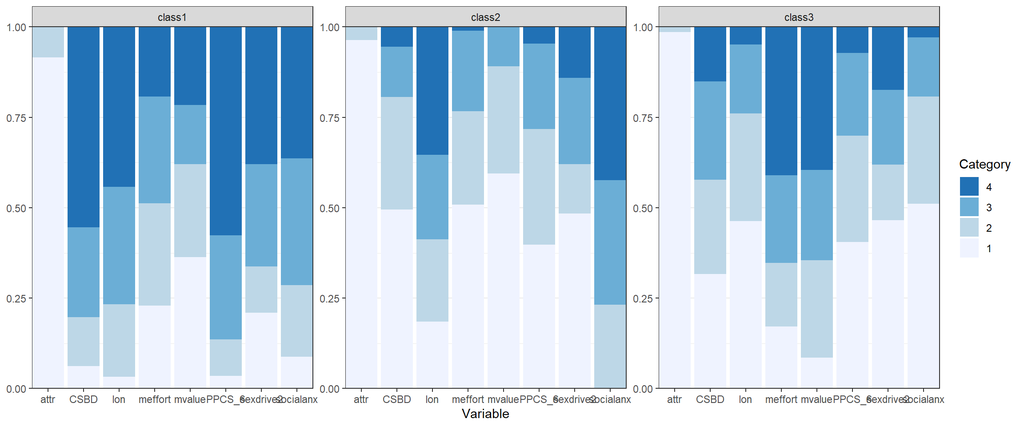

## Females

Now we redo the analysis with the subset of female participants. The cutoff values for fit indices obviously stay the same. It should be noted that two more variables needed to be dichotomised in the female sample, because they were also to skewed to form quantiles. Those were PPCS and CSBD.

### Scree Plot Females

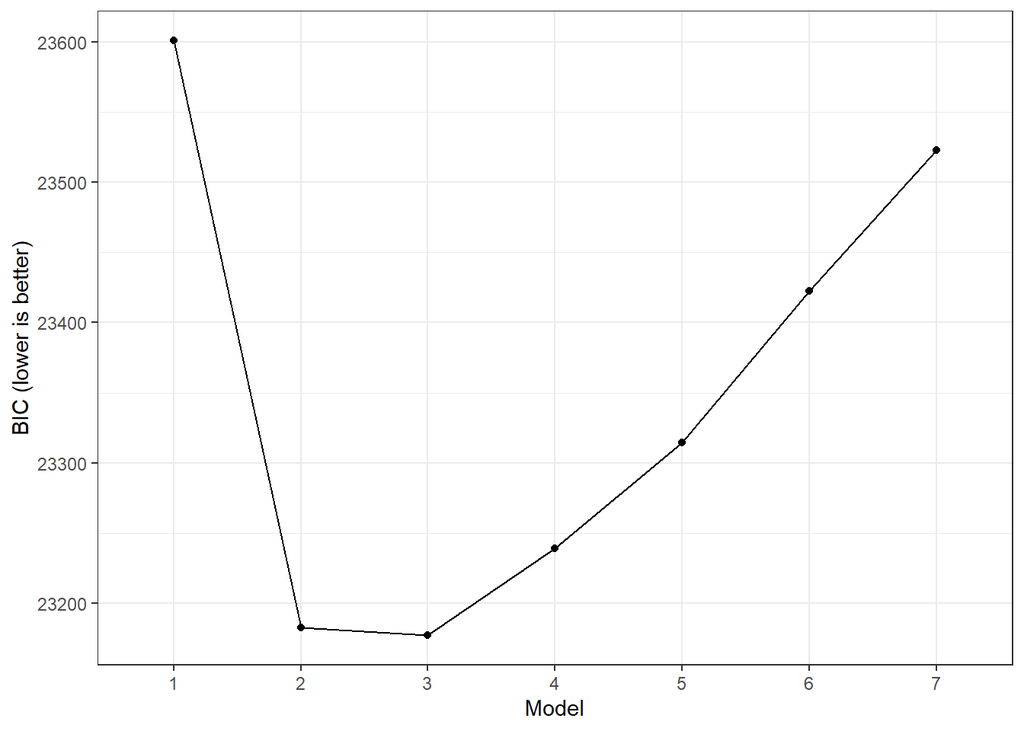

### Class Proportions Females

```
## $sum.posterior
##    class    count proportion
## 1 class1 295.1866  0.2078779
## 2 class2 621.5797  0.4377322
## 3 class3 503.2337  0.3543899
```

### Fit Table Females

```
##   Name        LL    n Parameters      BIC   Entropy  prob_min     n_min
## 1    1 -11735.05 1420         18 23600.76 1.0000000 1.0000000 1.0000000
## 2    2 -11457.01 1420         37 23182.58 0.6308272 0.8790804 0.4591549
## 3    3 -11385.34 1420         56 23177.16 0.6178119 0.6922488 0.1964789
## 4    4 -11347.35 1420         75 23239.08 0.6152313 0.6124101 0.1035211
## 5    5 -11316.24 1420         94 23314.76 0.6335429 0.6374424 0.1063380
## 6    6 -11301.20 1420        113 23422.59 0.6206997 0.6678337 0.0471831
## 7    7 -11282.23 1420        132 23522.56 0.6748439 0.6031259 0.0471831
##   np_ratio  np_local
## 1 78.88889 78.888889
## 2 38.37838 36.222222
## 3 25.35714 15.500000
## 4 18.93333  8.166667
## 5 15.10638  8.388889
## 6 12.56637  3.722222
## 7 10.75758  3.722222
```

### AvePP by Most Likely Class for Females

```
## $avg.mostlikely
##            meanprob.class1 meanprob.class2 meanprob.class3
## assigned.1      0.73241059      0.16003511      0.10755431
## assigned.2      0.08832127      0.84858392      0.06309481
## assigned.3      0.06903867      0.08876932      0.84219201
```

### Conditional Item Probabilities for Females

```
##     Variable Category Probability.class1 Probability.class2
## 1  sexdrive2        1         0.16147175      0.31591257984
## 2  sexdrive2        2         0.15952599      0.28243217693
## 3  sexdrive2        3         0.36667264      0.24421105886
## 4  sexdrive2        4         0.31232962      0.15744418438
## 5    meffort        1         0.03434664      0.25741716225
## 6    meffort        2         0.17437726      0.23803264856
## 7    meffort        3         0.35337251      0.30334513199
## 8    meffort        4         0.43790359      0.20120505720
## 9  socialanx        1         0.40231515      0.63104127606
## 10 socialanx        2         0.18419019      0.17132921428
## 11 socialanx        3         0.27832074      0.16844952647
## 12 socialanx        4         0.13517392      0.02917998319
## 13       lon        1         0.29041520      0.53853684010
## 14       lon        2         0.26523685      0.28359195019
```

[output cut: 39 more lines]

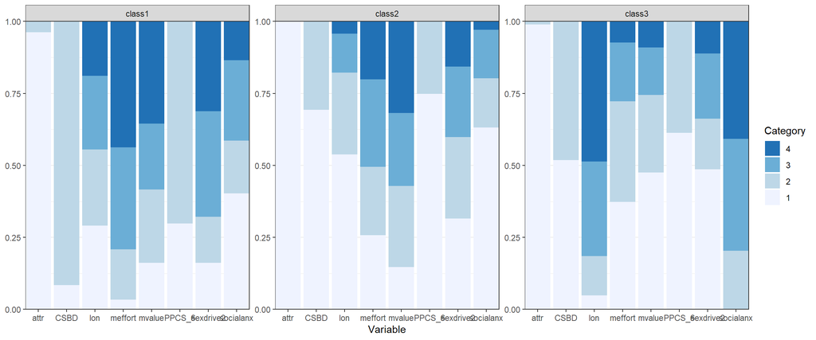

*References*

Clark, Shaunna L, and Bengt Muthén. 2009. “Relating Latent Class Analysis Results to Variables Not Included in the Analysis.” Los Angeles, California, USA.

Jeffries, Neal O. 2003. “A Note on ‘Testing the Number of Components in a Normal Mixture’.” *Biometrika* 90 (4): 991–94. https://doi.org/10.1093/biomet/90.4.991.

Masyn, Katherine E. 2013. *Latent Class Analysis and Finite Mixture Modeling*. Oxford University Press. https://doi.org/10.1093/oxfordhb/9780199934898.013.0025.

Nylund-Gibson, Karen, and Andrew Young Choi. 2018. “Ten Frequently Asked Questions about Latent Class Analysis.” *Translational Issues in Psychological Science* 4 (4): 440–61. https://doi.org/10.1037/tps0000176.

Van Lissa, C. J., M. Garnier-Villarreal, and D. Anadria. 2023. “Recommended Practices in Latent Class Analysis Using the Open-Source R-Package tidySEM.” *Structural Equation Modeling: A Multidisciplinary Journal*, October, 1–9. https://doi.org/10.1080/10705511.2023.2250920.

Wang, Meng-Cheng, Qiaowen Deng, Xiangyang Bi, Haosheng Ye, and Wendeng Yang. 2017. “Performance of the Entropy as an Index of Classification Accuracy in Latent Profile Analysis: A Monte Carlo Simulation Study.” *Acta Psychologica Sinica*.

Weller, Bridget E., Natasha K. Bowen, and Sarah J. Faubert. 2020. “Latent Class Analysis: A Guide to Best Practice.” *Journal of Black Psychology* 46 (4): 287–311. https://doi.org/10.1177/0095798420930932.